# Assignment #6 for DSSI

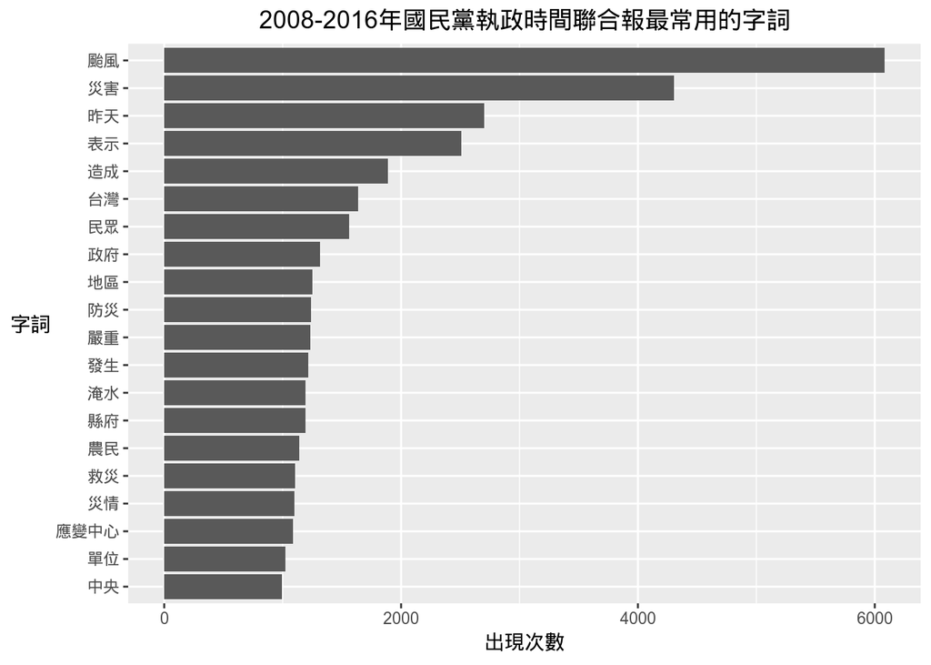

```r
# KMT的部份
unnested_KMT.df %>%
    count(word, sort=T) %>%
    filter(!(word %in% stopWords$word)) %>%
    filter(!str_detect(word, "[a-zA-Z0-9]+")) %>%
    filter(nchar(word) > 1) %>%
    filter(n > 3) %>%
    mutate(word = reorder(word, n)) %>%
  # 這裡取20筆就好
    slice(1:20) %>%
    ggplot() + aes(word, n)+
    ggtitle('2008-2016年國民黨執政時間聯合報最常用的字詞')+
    ylab('出現次數')+
    xlab('字詞')+
    geom_col() +
    coord_flip() +
    theme(axis.title.y=element_text(angle = 0,vjust = 0.5),plot.title = element_text(hjust = 0.5))
```

7. logratio：分析兩黨時期，聯合報所使用的用字差異

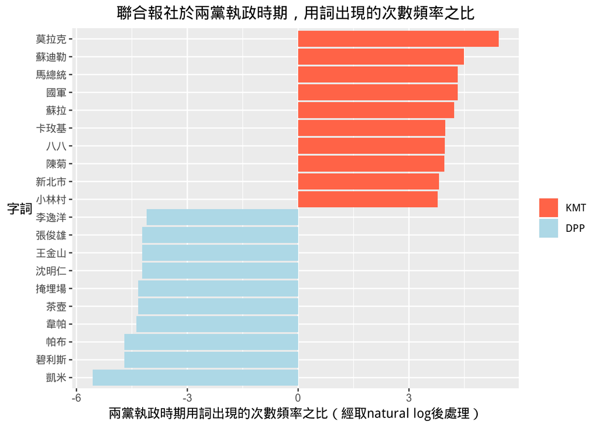

```r
# 統計用詞出現的次數
party_word.tf <- unnested.df %>%
  # 記數
    count(party, word) %>%
  # 一樣篩掉不想統計的東西
    filter(!str_detect(word, "[a-zA-Z0-9]+")) %>%
    filter(!(word %in% stopWords$word)) %>%
    filter(nchar(word)>1)

# 統計比例
party_ratio <- party_word.tf %>%
    filter(n>1) %>%
    spread(party, n, fill = 0) %>%
    ungroup() %>%
  # 計算比例，最後取log
    mutate_if(is.numeric, funs((. + 1) / sum(. + 1))) %>%
    mutate(logratio = log(KMT / DPP)) %>%
    arrange(desc(logratio))

# 畫圖
party_ratio %>%
    group_by(logratio > 0) %>%
    top_n(10, abs(logratio)) %>%
    ungroup() %>%
    mutate(word = reorder(word, logratio)) %>%
    ggplot(aes(word, logratio, fill = logratio < 0)) +
    geom_bar(stat = "identity") +
    coord_flip() +
    ggtitle('聯合報社於兩黨執政時期，用詞出現的次數頻率之比')+
    xlab('字詞')+
    ylab("兩黨執政時期用詞出現的次數頻率之比（經取natural log後處理）") +
    scale_fill_manual(name = "", labels = c("KMT","DPP"),values = c("tomato","lightblue")) +
    theme(axis.title.y=element_text(angle = 0,vjust = 0.5),plot.title = element_text(hjust = 0.5))
```

> 理論上而言，唯恐天下不亂的記者和媒體最愛在颱風天或是有災難出現的時候檢討當時的政府，而在兩黨執政期間因為總統不同，所以會檢討的對象也應該會不一樣，但扣除前幾名分別是颱風的名稱後，發現聯合報出現「馬總統」的比例真高啊，而且居然不是用本名「馬英九」，看得出聯合報真～的～有夠愛馬總統ㄉ啦！
8. scatter：用字頻率比較

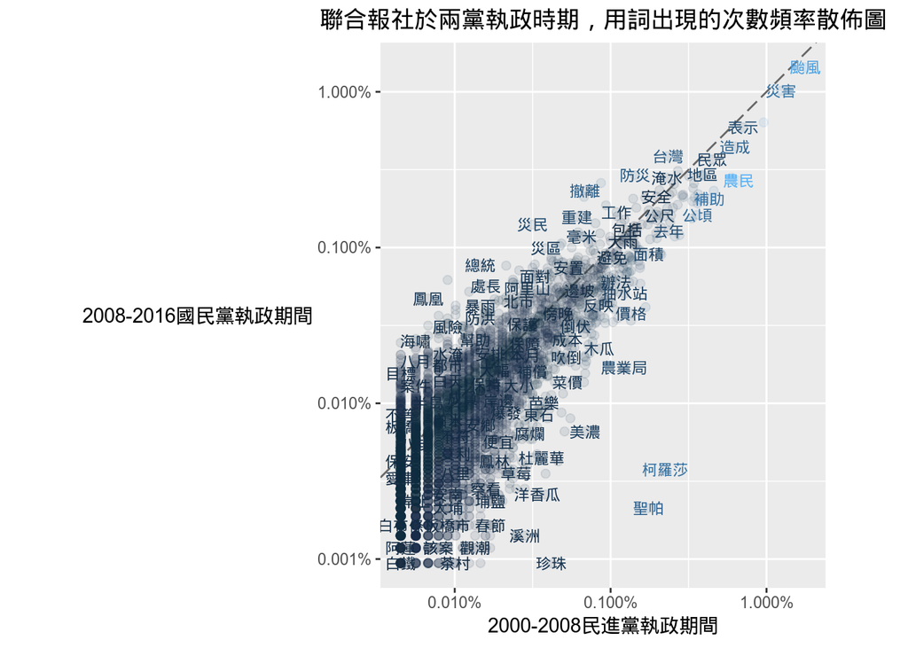

```r
# 分析用字的頻率，愈靠近兩軸代表愈靠近兩黨
frequency <- party_word.tf %>%
  # 一樣只篩出現次數大於三次的字詞
    filter(n>3) %>%
    group_by(party) %>%
    mutate(proportion = n/sum(n)) %>%
    select(-n) %>%
    spread(party, proportion) %>%
    na.omit()

# 畫圖
frequency %>%
ggplot(aes(x = DPP, y = KMT, color = abs(KMT - DPP))) +
    geom_abline(color = "gray40", lty = 5) +
    geom_point(alpha = 0.1, size = 2.0, width = 0.3, height = 0.3) +
    geom_text(aes(label = word), check_overlap = TRUE, size = 3) +
    theme(legend.position="none") +
  # 調整成取log_10的狀態，免得資料太過集中
    scale_x_log10(labels = percent_format()) +
    scale_y_log10(labels = percent_format()) +
    coord_fixed(1)+
    ggtitle('聯合報社於兩黨執政時期，用詞出現的次數頻率散佈圖')+
    xlab('2000-2008民進黨執政期間')+
    ylab('2008-2016國民黨執政期間')+
    theme(axis.title.y=element_text(angle = 0,vjust = 0.5),plot.title = element_text(hjust = 0.5))
```

> 其實我本來是要分析在兩黨部同執政期間，聯合報是否有媒體自助餐的現象。

> 我本來的預期是在因為聯合報很藍，所以在2000-2008這段阿扁執政期間發生的颱風災害，一定都會說是扁政府的問題，所以「政府」、「中央」這些字眼出現的頻率會高於馬政府時期；而2008-2016這段馬政府期間因為政府是主子、罵不得，所以大多都會說是地方政府的錯，所以「縣政府」、「市政府」等出現的頻率會高於扁政府期間，結果很吊詭的的並沒有很明顯的發現這樣的現象。

> 後來我想想可能可以歸咎於兩個原因。第一個就是上面的分析單單只採用「出現了」幾次當作頻率，而沒有考慮到「中央」或是「地方」政府出現的新聞可能不一樣。有可能這篇出現的「中央」是在怪罪中央政府沒有編列治水經費的缺失，但另一篇卻是用來稱讚「中央」在事後回復家園的時候處理的很好；這篇出現的「地方」可能是在說地方政府都沒有協助救災，但另一篇有可能是在說「地方」在這次災後有幫忙協助重建。我們應該還要考量到每一篇新聞是用持平、稱讚或是譴責的語氣去做分類，再從裡面分別抓出「中央」和「地方」的差別。

> 例如在2000-2008年期間，「稱讚」類的新聞有可能出現較多的「地方」，而「譴責」類的新聞可能會出現比較多的「中央」；而2008-2016年則是相反過來。這種語氣分類的方法可以從我們切出來的詞中分類、歸納出來，單單只用切出的詞作為計量其實是不夠的。

> 第二個就是「台灣媒體亂象」其實要一直到近十年才開始，基本上在2000年初期，媒體上還保持自律，還不太會用腥羶色的新聞內容博取點閱率，也還不會以奇怪或是聳動的標題吸引人們（如慟！驚！恐！悚！震憾彈！之類的用語），更不會將媒體當成攻擊另外一個政黨的工具。所以如果我們可以把時間拆分成「2008-2016」和「2016-至今」兩筆，可能才會看出所謂「媒體自助餐」的結果。